# 06_translate_flip_cbrt

## 06_translate_flip_cbrt

#### Question

1. Consider the $y=\sqrt[3]{x}$ curve (cube-root function) shown below. In the context of transforming functions, a very simple function is often called a “parent” function.

   The following 4 graphs are made by translating and reflecting the $y=\sqrt[3]{x}$ curve. So each one is a different daughter function, made by altering the parent function.

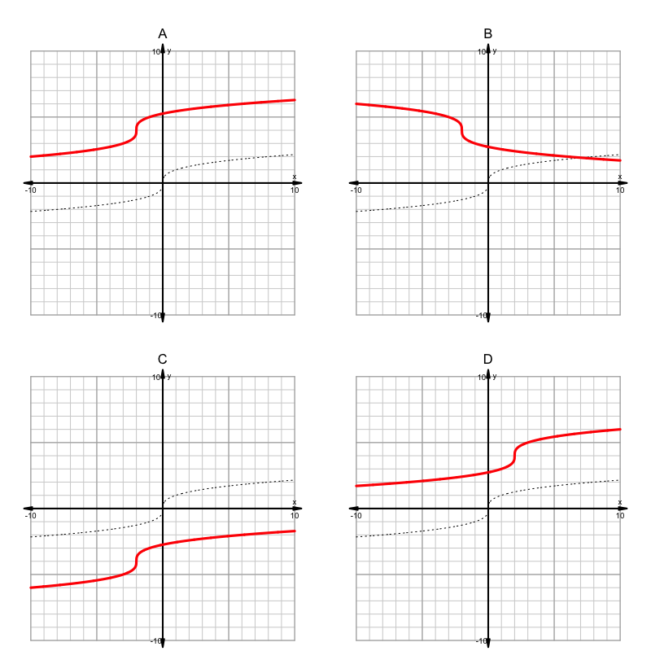

   Match the 4 graphs with the equations.
   1. Equation $y=-\sqrt[3]{-(x+2)}-4$ matches graph .
   2. Equation $y=-\sqrt[3]{-(x+2)}+4$ matches graph .
   3. Equation $y=\sqrt[3]{x-2}+4$ matches graph .
   4. Equation $y=\sqrt[3]{-(x+2)}+4$ matches graph .

#### Solution

#### Question

2. Consider the $y=\sqrt[3]{x}$ curve (cube-root function) shown below. In the context of transforming functions, a very simple function is often called a “parent” function.

   The following 4 graphs are made by translating and reflecting the $y=\sqrt[3]{x}$ curve. So each one is a different daughter function, made by altering the parent function.

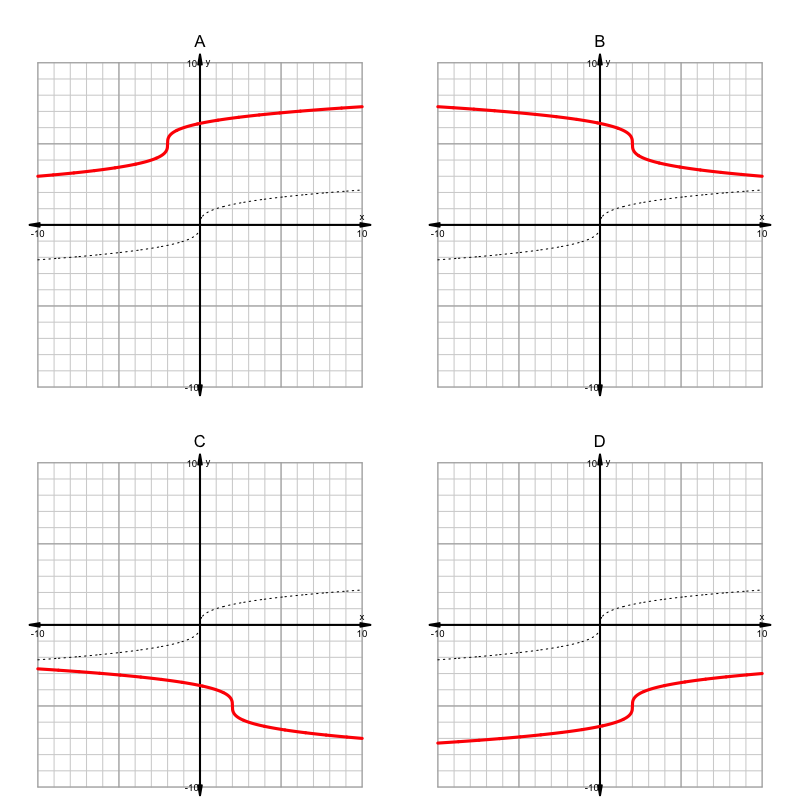

   Match the 4 graphs with the equations.
   1. Equation $y=\sqrt[3]{x-2}-5$ matches graph .
   2. Equation $y=\sqrt[3]{-(x-2)}+5$ matches graph .
   3. Equation $y=-\sqrt[3]{x-2}-5$ matches graph .
   4. Equation $y=-\sqrt[3]{-(x+2)}+5$ matches graph .

#### Solution

#### Question

3. Consider the $y=\sqrt[3]{x}$ curve (cube-root function) shown below. In the context of transforming functions, a very simple function is often called a “parent” function.

   The following 4 graphs are made by translating and reflecting the $y=\sqrt[3]{x}$ curve. So each one is a different daughter function, made by altering the parent function.

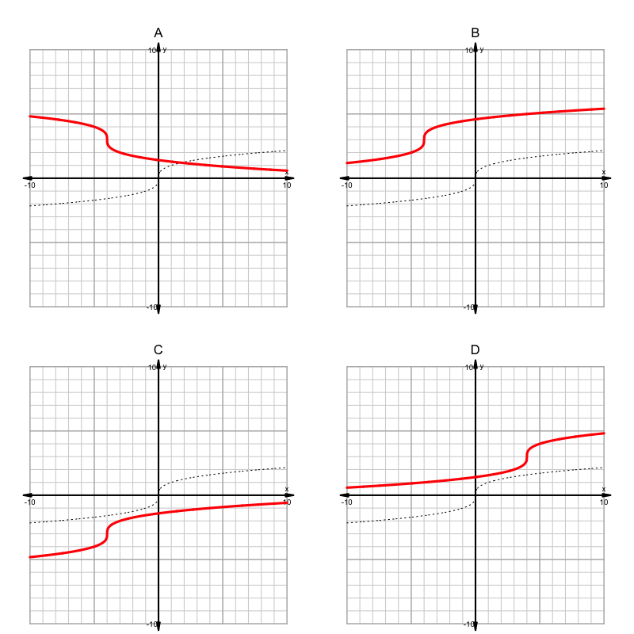

   Match the 4 graphs with the equations.
   1. Equation $y=\sqrt[3]{-(x+4)}+3$ matches graph .
   2. Equation $y=\sqrt[3]{x+4}+3$ matches graph .
   3. Equation $y=\sqrt[3]{x+4}-3$ matches graph .
   4. Equation $y=\sqrt[3]{x-4}+3$ matches graph .

#### Solution

#### Question

4. Consider the $y=\sqrt[3]{x}$ curve (cube-root function) shown below. In the context of transforming functions, a very simple function is often called a “parent” function.

   The following 4 graphs are made by translating and reflecting the $y=\sqrt[3]{x}$ curve. So each one is a different daughter function, made by altering the parent function.

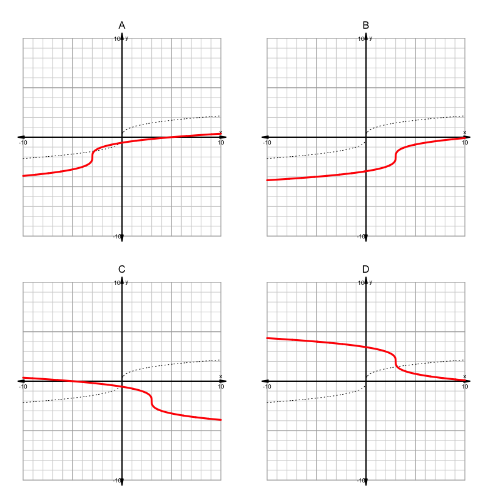

   Match the 4 graphs with the equations.
   1. Equation $y=-\sqrt[3]{x-3}+2$ matches graph .
   2. Equation $y=\sqrt[3]{x+3}-2$ matches graph .
   3. Equation $y=\sqrt[3]{-(x-3)}-2$ matches graph .
   4. Equation $y=-\sqrt[3]{-(x-3)}-2$ matches graph .

#### Solution

#### Question

5. Consider the $y=\sqrt[3]{x}$ curve (cube-root function) shown below. In the context of transforming functions, a very simple function is often called a “parent” function.

   The following 4 graphs are made by translating and reflecting the $y=\sqrt[3]{x}$ curve. So each one is a different daughter function, made by altering the parent function.

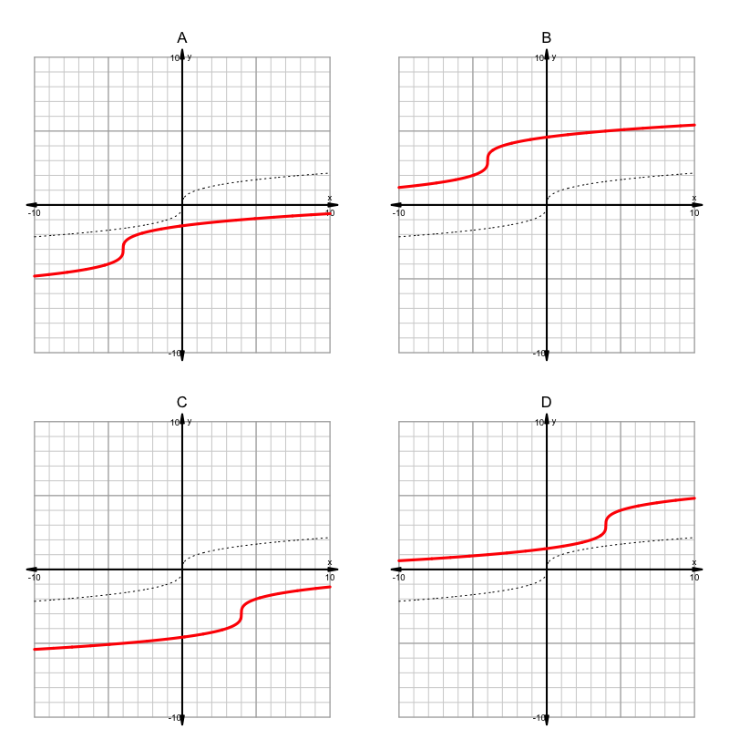

   Match the 4 graphs with the equations.
   1. Equation $y=-\sqrt[3]{-(x-4)}+3$ matches graph .
   2. Equation $y=\sqrt[3]{x-4}-3$ matches graph .
   3. Equation $y=-\sqrt[3]{-(x+4)}-3$ matches graph .
   4. Equation $y=\sqrt[3]{x+4}+3$ matches graph .

#### Solution

#### Question

6. Consider the $y=\sqrt[3]{x}$ curve (cube-root function) shown below. In the context of transforming functions, a very simple function is often called a “parent” function.

   The following 4 graphs are made by translating and reflecting the $y=\sqrt[3]{x}$ curve. So each one is a different daughter function, made by altering the parent function.

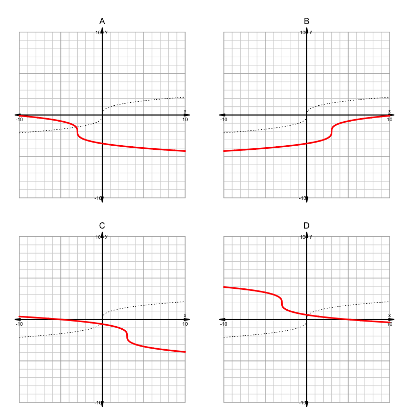

   Match the 4 graphs with the equations.
   1. Equation $y=\sqrt[3]{x-3}-2$ matches graph .
   2. Equation $y=\sqrt[3]{-(x+3)}-2$ matches graph .
   3. Equation $y=\sqrt[3]{-(x-3)}-2$ matches graph .
   4. Equation $y=-\sqrt[3]{x+3}+2$ matches graph .

#### Solution

#### Question

7. Consider the $y=\sqrt[3]{x}$ curve (cube-root function) shown below. In the context of transforming functions, a very simple function is often called a “parent” function.

   The following 4 graphs are made by translating and reflecting the $y=\sqrt[3]{x}$ curve. So each one is a different daughter function, made by altering the parent function.

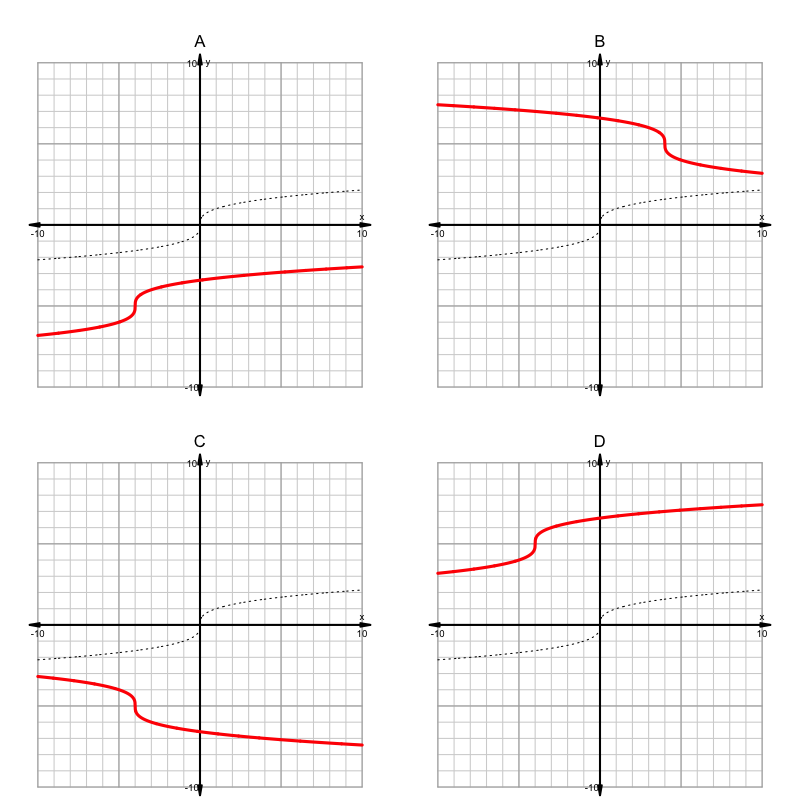

   Match the 4 graphs with the equations.
   1. Equation $y=\sqrt[3]{-(x-4)}+5$ matches graph .
   2. Equation $y=\sqrt[3]{-(x+4)}-5$ matches graph .
   3. Equation $y=\sqrt[3]{x+4}-5$ matches graph .
   4. Equation $y=-\sqrt[3]{-(x+4)}+5$ matches graph .

#### Solution

#### Question

8. Consider the $y=\sqrt[3]{x}$ curve (cube-root function) shown below. In the context of transforming functions, a very simple function is often called a “parent” function.

   The following 4 graphs are made by translating and reflecting the $y=\sqrt[3]{x}$ curve. So each one is a different daughter function, made by altering the parent function.

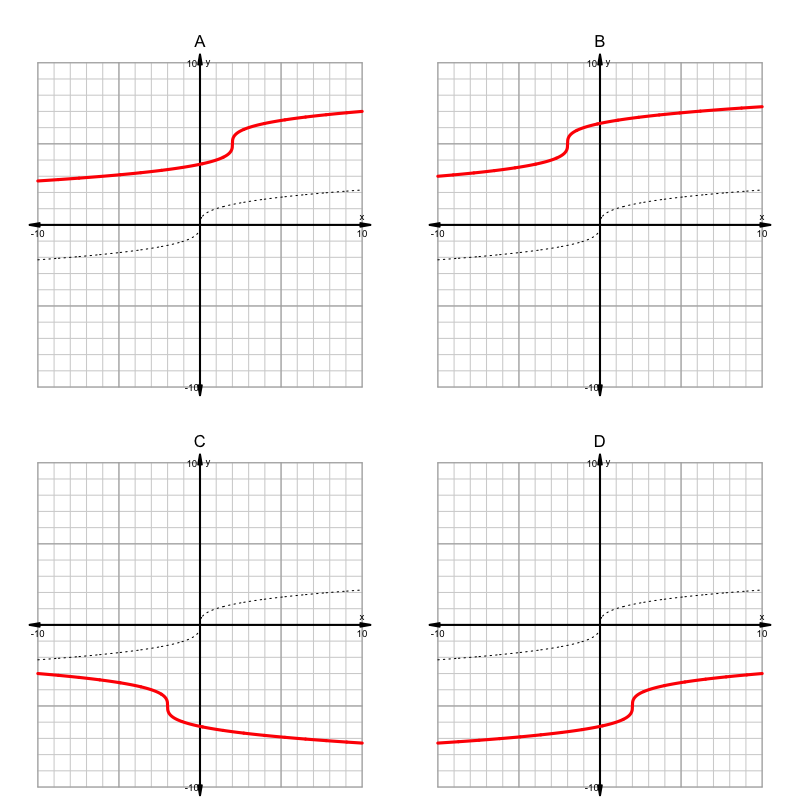

   Match the 4 graphs with the equations.
   1. Equation $y=\sqrt[3]{x-2}-5$ matches graph .
   2. Equation $y=\sqrt[3]{x-2}+5$ matches graph .
   3. Equation $y=-\sqrt[3]{-(x+2)}+5$ matches graph .
   4. Equation $y=-\sqrt[3]{x+2}-5$ matches graph .

#### Solution